# Tutorial of applying STEAM to evaluate clustering performance using the DLPFC spatial transcriptomic data

# Overview

This vignette outlines the steps of applying STEAM on the 10X Visium DLPFC (Dorsolateral Prefrontal Cortex) data. Four different classification models are implemented in STEAM to evaluate clustering results, including Random Forest, Support Vector Machines, XGBoost, and Multinomial Logistic Regression.

Here, cell-type classification is performed by incorporating spatial neighborhood analysis and Random Forest model with cross validation.

Before using STEAM, we recommend preprocessing your spatial transcriptomics data using the **Seurat** framework, as it provides a robust set of tools for spatial data normalization, scaling, and visualization. The Satija Lab offers detailed vignettes to guide you through spatial data preprocessing:

- [Seurat Spatial Vignette (Part 1)](https://satijalab.org/seurat/articles/spatial_vignette.html)
- [Seurat Spatial Vignette (Part 2 - Seurat v5)](https://satijalab.org/seurat/articles/spatial_v5.html)
- [Visium HD Analysis Vignette](https://satijalab.org/seurat/articles/spatial_hd.html)

To run STEAM, you need the following components:

- A normalized gene expression matrix
- An X,Y spatial coordinates matrix
- A vector of ground truth or predicted labels

# Load libraries

```r
library(STEAM)
library(Seurat)
```

# 1. Data Loading

# Load data

```r
DLPFCs <- readRDS("~/Desktop/STEAM/DLPFC/DLPFC12.RDS")
DLPFC <- DLPFCs$`151669`
```

## 1.1 Load from a Seurat object

**Parameters**

- `Seurat.obj` — a `Seurat` object with counts and metadata.
- `label.column` — metadata column containing the ground‑truthlabels (e.g., cortical layer, cell type).
- `assay` — which assay to read (e.g., `"SCT"`, `"RNA"`).

**Outputs** - `STEAM.obj$count_exp`, `STEAM.obj$labels`, `STEAM.obj$spatial` (if present in the Seurat object), and optional embeddings (PCA/UMAP) if available.

You can input this data into STEAM in two ways:

```r
STEAM.obj <- LoadSTEAM(
  Seurat.obj   = DLPFC,
  label.column = "Labels",
  assay        = "SCT"
)
```

```
## Using GetTissueCoordinates() to extract spatial data.
```

## 1.2 Load from matrices / data.frames

**Parameters**

- `count_exp` — expression matrix.
- `spatial` — coordinates; must align rownames with cell IDs used elsewhere.
- `labels` — named vector of reference labels (ground truth).
- `pca`, `umap`, `clusters` — optional; used for diagnostics/plots.

**Common checks** - Row/column names must be consistent across objects.

- No duplicated cell IDs.
- `labels` must cover all cells you plan to evaluate.

# 2. Train & Evaluate (Nested CV)

**Key parameters**

-`mode` — `"nested"` performs outer *and* inner cross‑validation (outer for unbiased evaluation; inner for tuning). -`n_outer_folds`, `n_inner_folds` — fold counts. -`cv.cores` — parallel workers for outer folds. -`allowParallel` — whether caret may parallelize inner CV (often `FALSE` to avoid nested parallelism contention). -`model`: The machine learning model to use for classification.

```
- `rf` = RandomForest
- `svm` = Support Vector Machines,
- `xgb` = XGBoost
- `multinom` = Multinomial Logistic Regression
```

- `metric` — caret optimization metric (e.g., `"Accuracy"`, `"Kappa"`).
- `maxnweights`, `n.size` — package‑specific compute/feature knobs.

**Outputs**

- `STEAM.obj$nested$ncv` — nested CV object containing:
- `outer_result[[i]]$preds` — **outer test predictions** per fold with `predy` (prediction), `testy` (truth), and per‑class probabilities.
- `outer_result[[i]]$fit$pred` — **inner CV predictions** used for tuning.

```r
STEAM.obj <- RunSTEAM(
  STEAM.obj, mode = "nested",
  n_outer_folds = 5, n_inner_folds = 3,
  cv.cores = 10,
  allowParallel = FALSE,
  n.size = 5,
  model = "rf",
  metric = "Kappa",
  maxnweights = 15000
)
```

```
## Creating nested CV folds using method: stratified
```

```
## === STRATIFIED CV DIAGNOSTICS ===
```

```
## Method used: stratified
```

```
## Outer folds: 5
```

```
## Fold sizes: 729, 727, 727, 727, 726
```

```
## Fold size balance ratio: 1
```

```
## Overall class balance ratio: 1.01 (closer to 1.0 = better balance)
```

```
##
## === STRATIFICATION QUALITY METRICS ===
```

```
## Overall Quality Index: 0.981 (0-1 scale, higher = better, calibrated)
```

```
## Overall Chi-squared: 0.023 (lower = better, threshold=47.4)
```

```
## Overall CV: 0.003 (lower = better, threshold=0.3)
```

```
## Overall MAD: 0.001 (lower = better, threshold=0.294)
```

```
##
## Normalized penalty components:
```

```
##   Chi-squared penalty: 0 (weight: 0.4)
```

```
##   CV penalty: 0.009 (weight: 0.35)
```

```
##   MAD penalty: 0.002 (weight: 0.25)
```

```
##   Combined penalty: 0.004 (0=perfect, 1=poor)
```

```
##
## Per-class quality metrics:
```

```
##   Layer_4: χ²=0.011, CV=0.005, MAD=0.001, p=1
```

```
##   Layer_6: χ²=0.01, CV=0.004, MAD=0.001, p=1
```

```
##   Layer_3: χ²=0.002, CV=0.001, MAD=0.001, p=1
```

```
##   WM: χ²=0, CV=0.002, MAD=0, p=1
```

```
##   Layer_5: χ²=0, CV=0.002, MAD=0, p=1
```

```
##
## EXCELLENT stratification quality
```

```
##
## Class distributions per fold:
```

```
##   Fold 1: Layer_3:429, Layer_4:73, Layer_5:102, Layer_6:79, WM:46
```

```
##   Fold 2: Layer_3:428, Layer_4:73, Layer_5:102, Layer_6:78, WM:46
```

```
##   Fold 3: Layer_3:428, Layer_4:73, Layer_5:102, Layer_6:78, WM:46
```

```
##   Fold 4: Layer_3:428, Layer_4:73, Layer_5:102, Layer_6:78, WM:46
```

```
##   Fold 5: Layer_3:428, Layer_4:72, Layer_5:102, Layer_6:78, WM:46
```

```
## Performing 5-fold outer CV, using 10 cores
```

```
## Duration: 3.891429 mins
```

```
## Finished NestedCV training (outer+inner with leakage-safe averaging)
```

```
## Collected NestedCV results
```

# 2.1. Evaluation & Diagnostics

- `ViewMetrics()` — tabular summaries overall / per fold.
- `plot_misclassified_cells()` — visualize errors spatially or by fold.
- `feature_importance()` — model‑specific importance (e.g., RF Gini/perm).
- `feature_expression()` — expression of a gene/feature in different views.

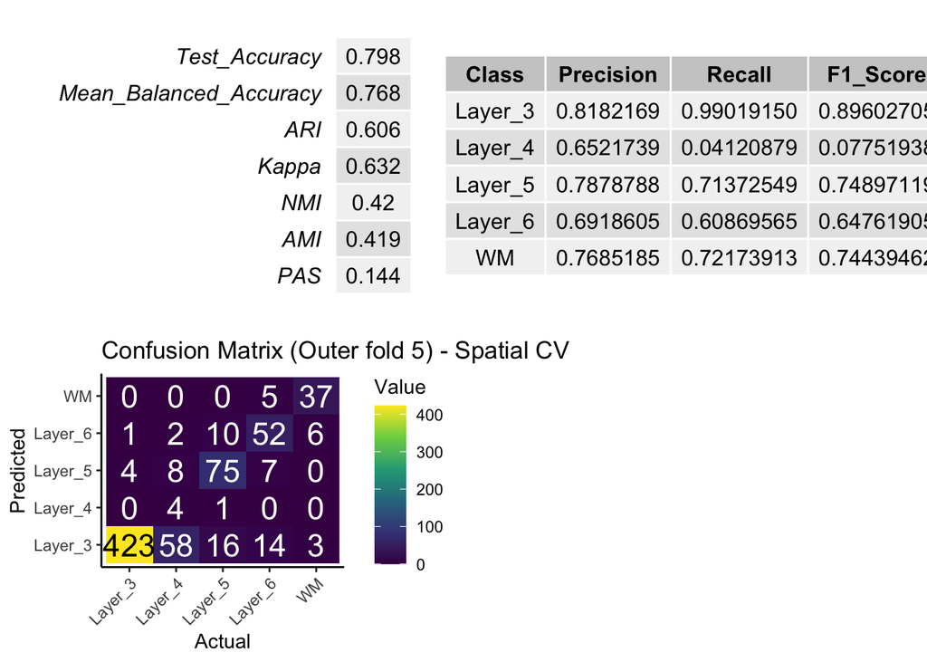

```r
ViewMetrics(STEAM.obj, view = "overall")
```

```r
# To view specific folds: ViewMetrics(STEAM.obj, fold = 1)
```

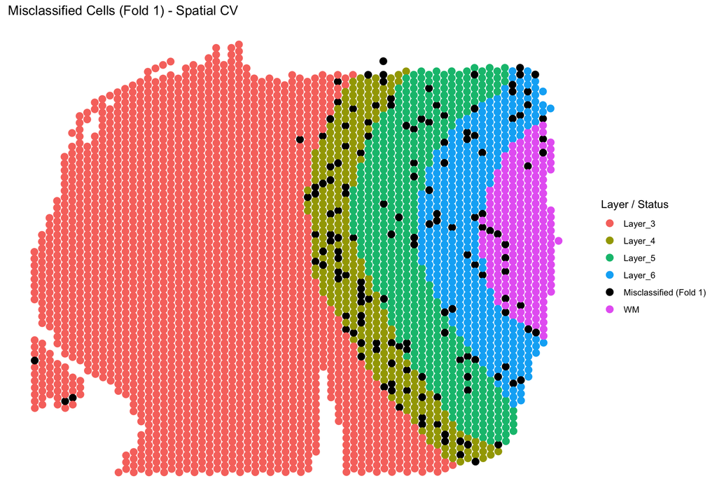

```r
plot_misclassified_cells(STEAM.obj, fold = 1)
```

```r
# plot all misclassified cells across all folds
# plot_misclassified_cells(STEAM.obj)
```

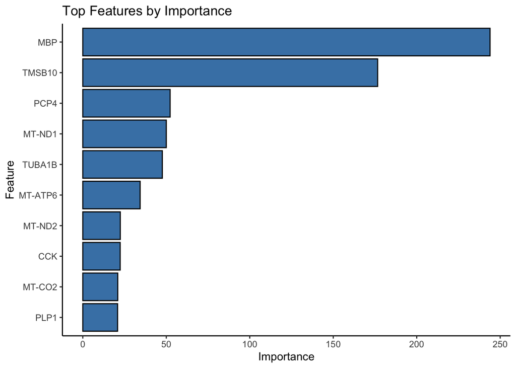

```
##       MBP    TMSB10      PCP4    MT-ND1    TUBA1B   MT-ATP6    MT-ND2       CCK
## 243.90331 176.59116  52.30314  49.99903  47.62671  34.33483  22.45673  22.39446
##    MT-CO2      PLP1
##  20.94168  20.82675
```

```r
feature_importance(STEAM.obj)
```

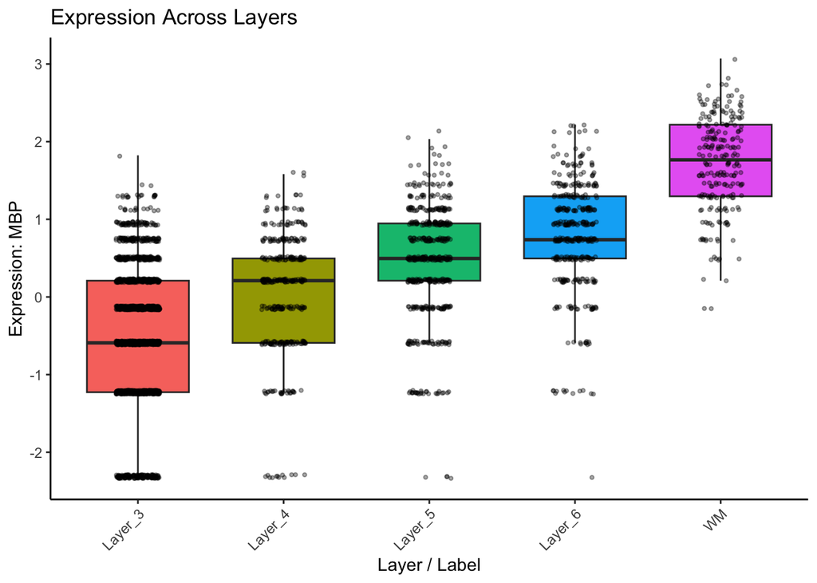

```r
feature_expression(STEAM.obj, "MBP", view = "pooled")
```

```r
#feature_expression(STEAM.obj, "MBP", view = "facet")
```